# Control Estadístico

### Índice Cp

Es un indicador de la capacidad potencial del proceso.

$$C_p = \frac{Variación Tolerada}{Variación Real}$$

Entonces:

$$C_p = \frac{ES-EI}{6\sigma}$$

Ejemplo:

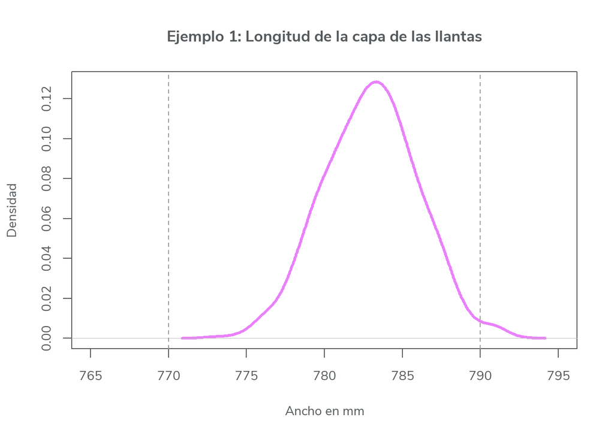

```r
plot(density(rnorm(780, 783, 3)),
     xlim = c(765, 795),
     type = "l",
     col = "#EA80FC",
     lwd = 3,
     xlab = "Ancho en mm",
     ylab = "Densidad",
     main = "Ejemplo 1: Longitud de la capa de las llantas")
abline(v = 770, col = "grey60", lty = 2)
abline(v = 790, col = "grey60", lty = 2)
```

Como podemos ver el proceso no está centrado:

```r
ES <- 790
EI <- 770
Variacion_tolerada <- ES - EI
Variacion_real <- 6*(3)
Cp <- Variacion_tolerada/Variacion_real;paste("CP =",round(Cp, digits = 2), sep = " ")
```

```
[1] "CP = 1.11"
```

| Indice Cp | Clase | Decisión |
| --- | --- | --- |
| Cp ≥ 2 | Clase mundial | Se tiene calidad Seis Sigma |
| Cp > 1.33 | 1 | Adecuado |
| 1 < Cp < 1.33 | 2 | Parcialmente Adecuado, requiere de un control estricto |
| 0.67 < Cp < 1 | 3 | No adecuado para el trabajo, modificaciones serias |
| Cp < 0.67 | 4 | No adecuado para el trabajo, modificaciones muy serias |

### Índice Cr

Es un indicador de la capacidad potencial del proceso. Representa la proporción de la banda de especificaciones que es cubierta por el proceso.

```r
ES <- 790
EI <- 770
Variacion_real <- 6*(3)
Variacion_tolerada <- ES - EI
Cr <- Variacion_real/Variacion_tolerada;paste("Cr =",round(Cr, digits = 2), sep = " ")
```

```
[1] "Cr = 0.9"
```

Esto nos indica que la variación del proceso potencialmente cubre el 90% de la banda de especificaciones > Nota: Estos dos índices no toman en cuenta si el proceso se encuentra centrado lo cual se puede observar a partir de la figura la cual es una desventaja para estos dos índices.

### Índice Cpi

Indicador de la capacidad de un proceso para cumplir con la especificación inferior de una característica de calidad.

$$C_{pi}=\frac{\mu-EI}{3\sigma}$$

```r
mu <- 783
Cpi <- (mu-EI)/(3*(3));paste("Cpi =",round(Cpi, digits = 2), sep = " ")
```

```
[1] "Cpi = 1.44"
```

Como se puede ver si el indice supera el 1 y específicamente es mayor que 1.25 se puede decir que la especificación inferior es adecuada.

### Índice Cps

Indicador de la capacidad de un proceso para cumplir con la especificación superior de una característica de calidad.

$$C_{ps}=\frac{ES-\mu}{3\sigma}$$

```r
Cps <- (ES-mu)/(3*(3));paste("Cps",round(Cps, digits = 2),sep = " ")
```

```
[1] "Cps 0.78"
```

> Nota: Como vemos en este caso se puede obtener un índice que si toma en cuenta el centrado del proceso es decir se utiliza la media y claro como es la mitad de la distribución se utiliza 3 sigma.

### Índice Cpk

Es un indicador de la capacidad real de un proceso que se puede ver como un ajuste del $C_p$ para tomar en cuenta el centrado del proceso.

$$C_{pk} = Mínimo \left[\frac{\mu-EI}{3\sigma} ,
\frac{ES-\mu}{3\sigma}\right] \\
Mínimo \left[\frac{783-770}{3*3} , \frac{790-783}{3*3}\right]= \\
Mínimo [1.44,0.78] = 0.78$$

```r
Cpk <- min(c(Cpi, Cps));paste("Cpk =",round(Cpk, digits = 2), sep = " ")
```

```
[1] "Cpk = 0.78"
```

En general el proceso indica una capacidad no satisfactoria. El porcentaje de de capas que exceden los 790 mm se encuentran entre 0.82% y 1.79%. Entonces si mejora su centrado alcanzaría el valor del $C_p = 1.11$

### Índice K

Nos indica que tan centrado está un proceso respecto a las especificaciones dadas.

$$K = \frac{\mu - N}{\frac{1}{2}(ES-EI)} \times 100 \\
= \frac{783 - 780}{\frac{1}{2}(790-770)} \times 100 = 30\%$$

```r
N <- 780
k <- (mu-N)/(1/2*(ES-EI))*100;paste("k = ",k, "%",sep = "")
```

```
[1] "k = 30%"
```

Esto nos dice que el proceso está desviado $30\%$ a la derecha del valor nominal por lo que el centrado del proceso es inadecuado y esto contribuye de manera significativa a la baja capacidad del proceso de cumplir con la especificación superior anterior mencionada.

### Índice Cpm

Índice de **Taguchi** similar al $C_{pk}$ que, en forma simultanea, toma en cuenta el centrado y la variabilidad del proceso.

$$C_{pm} = \frac{ES-EI}{6\tau} \\
\tau = \sqrt{\sigma^2+(\mu-N)^2}\\
N = 0.5(ES+EI)$$

Entonces:

$$C_{pm} = \frac{ES-EI}{6\sqrt{\sigma^2+(\mu-0.5(ES+EI))^2}} \\
C_{pm} = \frac{20}{25.46} = 0.79$$

| Índice | Desición |
| --- | --- |
| Cpm < 1 | El proceso no cumple con especificaciones |
| Cpm > 1 | El proceso cumple con especificaciones |
| Cpm > 1.33 | El proceso cumple con especificaciones, pero además la media del proceso está dentro de la quinta parte central de la banda de especificación |

```r
Cpm <- (ES-EI)/(6*sqrt((3^2)+(mu-0.5*(ES+EI))^2));paste("Cpm = ",round(Cpm, digits = 2),sep = "")
```

```
[1] "Cpm = 0.79"
```

Lo que quiere decir es que como es menor a 1, el proceso no cumple con especificaciones.

### Índice Pp

Indicador del desempeño potencial del proceso que se calcula de forma similar al índice $C_p$ pero usando la desviación estándar de largo plazo.

Este índice se no toma el centrado del proceso por el cual se complemente con el $P_pk$

$$P_p = \frac{ES-EI}{6\sigma_L} \rightarrow Desempeño \space del \space
proceso \space a \space largo \space plazo$$

### Índice Ppk

Indicador del desempeño real del proceso, que se calcula de forma similar al indice $C_{pk}$ pero usando la desviación estándar de largo plazo.

$$P_{pk} = mínimo
\left[\frac{\mu-EI}{3\sigma_L},\frac{ES-\mu}{3\sigma_L}\right]$$

> Nota: Se utiliza igual que el Cpk solo que se utiliza un sigma sub L, lo cual significa que es de largo plazo.

### Índice Z

Es la métrica de capacidad de procesos de mayor uso en Seis Sigma. Se obtiene calculando la distancia entre la media y las especificaciones y esta distancia se divide entre la desviación estándar.

$$Z = mínimo[Z_s - Z_i]$$

Entonces:

$$Z_s = \frac{ES-\mu}{\sigma}$$

$$Z_i = \frac{\mu-EI}{\sigma}$$

> Nota: Este índice tiene la calidad de 3 sigma.

### Índice Zm

Desplazamiento o movimiento del proceso.

$$Z_m = Z_c-Z_L$$

#### Índice Zc

Valor del índice Z en el cual se emplea la desviación estándar de corto plazo.

#### Índice ZL

Valor del índice Z en el cual se emplea la desviación estándar de largo plazo.

| Índice | Desición |
| --- | --- |
| Zm < 1.5 | El proceso tiene un mejor control que el promedio |
| Zm > 1.5 | El control es muy malo |
| Zm No se conoce | Se asume un valor de 1.5 |

### Proceso Tres Sigma

Proceso cuya capacidad para cumplir con especificaciones a corto plazo es igual a $Z_c=3$ y el índice es $C_{pk}=1$

> Nota La calidad 3 sigma implica demaciados errores. En este caso los índices C_p y el C_pk = 1. Cuando es 3 sigma el pasar del tiempo hace que quede fuera de las especificaciones.

Proceso cuya capacidad para cumplir con especificaciones a corto plazo es igual a $Z_c=6$ o cuando es a largo plazo significa $Z_{L}= 4.5$, lo cual, a corto plazo significa $C_{pk}=2$ y a largo plazo $P_{pk}=1.5$

### Metricas Seis Sigma para atributos

#### DPMO

Cuando las características de calidad son para atributos. Existe un índice que nos permite ver los defectos por unidades.

$$DPU = \frac{d}{U}$$

Ejemplo: En el proceso de ensamble de un mueble existen 24 puntos de ensamble entonces en la inspección final se evaluan cada punto de ensamble. Al final del mes se tiene que de 2000 muebles revisados se encontraron 120 puntos de ensamble insatisfactorios.

$$DPU = \frac{120}{2000}=
0.06$$

Lo que quiere decir es que en promedio cada silla tiene 0.06 ensambles defectuosos y que en 100 sillas se esperarían 6 ensambles defectuosos.

Los defectos por oportunidad que mide la no calidad de un proceso es:

$$DPO = \frac{120}{2000\times
24}=\frac{120}{48000}= 0.0025 \times 1000000 = 2500$$

Lo que quiere decir que de 1000000 de ensambles realizados se espera tener 2500 con algún tipo de defecto.

### Estimaciones por intervalo de los índices de capacidad

$$\hat{C_p} \pm Z_{\infty/2} \frac{\hat{C_p}}{\sqrt{2(n-1)}}$$

$$\hat{C_{pk}} \pm Z_{\infty/2}
\sqrt{\frac{\hat{C^2_{pk}}}{2(n-1)}+\frac{1}{9n}}$$

$$\hat{C_{pm}} \pm Z_{\infty/2} \frac{\hat{C_{pm}}}{\sqrt{n}}
\sqrt{\frac{\frac{1}{2}+\frac{(\bar{X}-N)^2}{S^2}}{\left[1+\frac{(\bar{X}-N)^2}{S^2}\right]^2}}$$

### Causas Comunes y Especiales de Variación

Existen dos tipo de variabilidad:

- Causas Comunes (Azar): Está en control estadístico o es estable porque su comportamiento atraves del tiempo es predecible.
- Causas Especiales o Atribuibles: Está fuera control estadístico o es inestable ya que son impredecibles en el futuro inmediato.

Es muy importante tomar en cuenta los tipos de errores que existen:

- Error Tipo 1: Pensar que era una causa especial cuando en realidad era una causa común.
- Error Tipo 2: Pensar que era una causa común cuando en realidad era una causa especial.

> Nota: Se puede evitar uno u otro pero no ambos.

### Cartas de control

Es una gráfica para observar y analizar la variabilidad y el comportamiento de un proceso a través del tiempo.

### Límites de probabilidad

Es cuando los límites de control se calculan con la distribución de probabilidad del estadístico para que logren un porcentaje de cobertura específico.

Si la distribuidora es unimodal pero no normal se aplica el teorema de Chebyshev.

$$LCI = \mu_w - 3\sigma_w\\
Línea \space central = \mu_w\\
LCS = \mu_w + 3\sigma_w$$

> Nota: Si W tiene un comportamiento normal tendra una probabilidad de 0.9973 de caer en dentro de las especificaciones.

### Tipos de Cartas de control

#### Cartas de Control Variables

Para variables continuas:

- $\bar{X}$ (de medias)
- $R$ (de rangos)
- $S$ (de desviaciones estándar)
- $X$ (de medidas individuales)

> Nota: Estos son recogidos con un instrumento. Estas variables por ejemplo la temperatura, peso, longitud, etc.

#### Cartas de Control Atributos

- $p$ (proporción o fracción de artículos defectuosos)
- $np$ (número de unidades defectuosas)
- $c$ (número de defectos)
- $u$ (número de defectos por unidad)

> Nota: Son del tipo conforme o no conforme depende de si posee o no ciertos atributos, número de defectos o no conformidades que tiene el producto.

### Cartas de Control $\bar{X} - R$

Diagramas para variables que se aplican a procesos masivos, en donde de forma periódica se obtiene un subgrupo de productos, se miden y se calcula la media y el rango R para registrarlos en la carta correspondiente.

**La carta R** detecta cambios significativos en la amplitud de la dispersión. Por ejemplo, si la variabilidad aumenta (una campana más amplia), la carta R lo detecta mediante uno o más puntos fuera de su LCS (Límite de control superior).

**La carta $\bar{X}$** detecta cambios significativos en la media del proceso. Cuando la curva se desplaza la carta manda una o varias señales de fuera de control.

Tomando esto en cuenta tenemos los siguientes *límites de control:*

#### Estudio Inicial Carta $\bar{X}$

$$LCS = \bar{X}+A_2\bar{R} \\
Línea \space central = \bar{X} \\
LCS = \bar{X}-A_2\bar{R}$$

#### Carta cuando se conoce $\bar{X}$ y $\sigma$

$$LCS = \bar{X}+ 3 \frac{\sigma}{\sqrt{n}} \\
Línea \space central = \bar{X} \\
LCS = \bar{X}- 3 \frac{\sigma}{\sqrt{n}}$$

### Ejemplo

#### ETL

```r
ejemplo1 <- openxlsx::read.xlsx("C:\\Users\\Criss\\Documents\\Complexivo\\Control\\Libro1.xlsx",
                                sheet = "Hoja2",
                                rows = c(97:127),
                                cols = c(2:7))
ejemplo1 <- ejemplo1 %>%
  rename(Muestra = Muestra.o.subgrupo,
         X2 = Mediciones.del.diametro)%>% pivot_longer(c(2:6),
                                      names_to = "Submuestra",
                                      values_to = "Mediciones")
ejemplo1_med <- ejemplo1 %>%
  group_by(Muestra) %>%
  summarise(Media = mean(Mediciones),
            Rango = max(Mediciones)-min(Mediciones))
media_promedio <- mean(ejemplo1_med$Media)
media_rango <- mean(ejemplo1_med$Rango)
LCS <- media_promedio+0.577*(media_rango)
LC <- media_promedio
LCI <- media_promedio-0.577*(media_rango)

ejemplo1_med$LCS <- LCS
ejemplo1_med$LC <- LC
ejemplo1_med$LCI <- LCI
D4 <- 2.1144
D3 <- 0
LCS_R <- D4*(media_rango)
LC_R <- media_rango
LCI_R <- D3*(media_rango)

ejemplo1_med$LCS_R <- LCS_R
ejemplo1_med$LC_R <- LC_R
ejemplo1_med$LCI_R <- LCI_R
ejemplo1_med
```

| Muestra | Media | Rango | LCS | LC | LCI | LCS_R | LC_R | LCI_R |
| --- | --- | --- | --- | --- | --- | --- | --- | --- |
| 1 | -2.8 | 42 | 15.76843 | 0.5933333 | -14.58177 | 55.60872 | 26.3 | 0 |
| 2 | 3.6 | 40 | 15.76843 | 0.5933333 | -14.58177 | 55.60872 | 26.3 | 0 |
| 3 | -3.4 | 20 | 15.76843 | 0.5933333 | -14.58177 | 55.60872 | 26.3 | 0 |
| 4 | 10.2 | 30 | 15.76843 | 0.5933333 | -14.58177 | 55.60872 | 26.3 | 0 |
| 5 | 1.0 | 33 | 15.76843 | 0.5933333 | -14.58177 | 55.60872 | 26.3 | 0 |
| 6 | 1.4 | 19 | 15.76843 | 0.5933333 | -14.58177 | 55.60872 | 26.3 | 0 |
| 7 | 0.8 | 16 | 15.76843 | 0.5933333 | -14.58177 | 55.60872 | 26.3 | 0 |
| 8 | -2.2 | 22 | 15.76843 | 0.5933333 | -14.58177 | 55.60872 | 26.3 | 0 |
| 9 | 5.4 | 11 | 15.76843 | 0.5933333 | -14.58177 | 55.60872 | 26.3 | 0 |
| 10 | -1.0 | 40 | 15.76843 | 0.5933333 | -14.58177 | 55.60872 | 26.3 | 0 |

[output cut: 20 more lines]

#### Gráfica $\bar{X}$

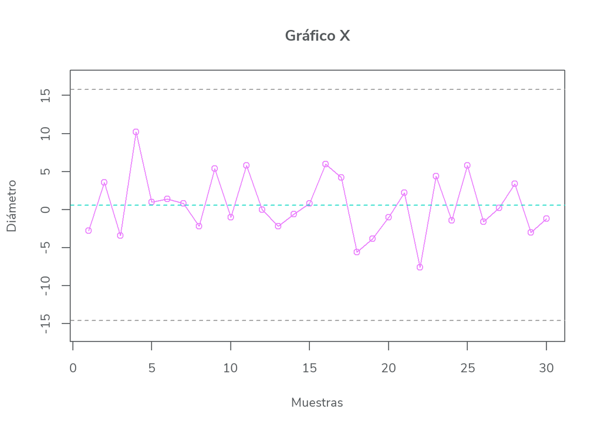

```r
plot(ejemplo1_med$Media, type = "o",
     ylim = c(-16,17),
     ylab = "Diámetro",
     xlab = "Muestras",
     main = "Gráfico X",
     col = "#EA80FC")
abline(h = ejemplo1_med$LCS, col = "grey60",lty = 2)
abline(h = ejemplo1_med$LC, col = "#00DAC6", lty = 2)
abline(h = ejemplo1_med$LCI, col = "grey60", lty = 2)
```

#### Gráfica $R$

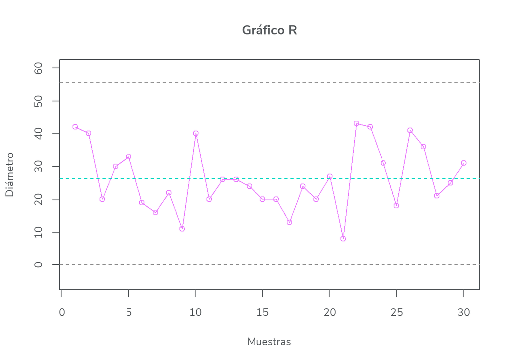

```r
plot(ejemplo1_med$Rango, type = "o",
     ylim = c(-5,60),
     ylab = "Diámetro",
     xlab = "Muestras",
     main = "Gráfico R",
     col = "#EA80FC")
abline(h = ejemplo1_med$LCS_R, col = "grey60",lty = 2)
abline(h = ejemplo1_med$LC_R, col = "#00DAC6", lty = 2)
abline(h = ejemplo1_med$LCI_R, col = "grey60", lty = 2)
```

### Cartas de Control $\bar{X} - S$

Diagrama para variables que se aplican a procesos masivos, en los quiere tener una mayor potencia para detectar pequeños cambios. Por lo general, el tamaño de los subgrupos es $n>10$.

#### Carta $\bar{X}$

$$LCS = \bar{X} + 3 \frac{\bar{S}}{C_4 \sqrt{n}}\\
LC = \bar{X}\\
LCI = \bar{X} - 3 \frac{\bar{S}}{C_4 \sqrt{n}}$$

#### Carta $S$

$$LCS = \bar{S} + 3 \frac{\bar{S}}{C_4}\sqrt{1-C^2_4}\\
LC = \bar{S}\\
LCI = \bar{S} - 3 \frac{\bar{S}}{C_4} \sqrt{1-C^2_4}$$

### Índice de inestabilidad $, S_t$

Mide que tan inestable es un proceso y se obtiene dividiendo el número de puntos especiales entre el total de puntos graficados en una carta.

$$S_t = \frac{Número \space de \space puntos \space especiales}{Número
\space total \space de \space puntos} \times 100$$

> Proceso Inestable

Proceso fuera de control estadístico que se detecta cuando en la carta de control los puntos están fuera de sus límites o siguen un patrón no aleatorio.

> Puntos Especiales

Son señales de que una causa especial ocurrio en el proceso

### Carta de individuales

Es un diagrama para variables de tipo continuo que se aplica a procesos lentos, donde hay un espacio largo de tiempo entre una medición y la siguiente.

$$\mu_X = \bar{X} \space y \space
\sigma_x=\frac{\bar{R}}{d_2}=\frac{\bar{R}}{1.128}\\
\bar{X} \pm 3 \left(\frac{\bar{R}}{1.128}\right)$$

### Carta de Rangos Moviles

Carta que acompaña a la carta de individuales, y en ella se grafica el rango móvil de orden 2. Es de utilidad para detectar cambios en la dispersión de procesos.

Límite de control inferior $= D_3 \bar{R} = 0 \times 0.43 = 0$

Límite central $= \bar{R} = 0.43$

Límite de control superior $= D_4 \bar{R} = 3.2686 \times 0.43 = 1.41$

### Carta de Precontrol

Diagrama para variables con doble especificación en donde se grafican las mediciones individuales, utiliza las especificaciones como límites de control y se aplica cuando $C_{pk}> 1.15$

### Carta $p$ (proporción de defectos)

Muestras las variaciones en la fracción de artículos por muestra o subgrupo; es ampliamente utilizada para evaluar el desempeño de procesos.

> Articulos defectuosos Es un producto que no reune ciertos atributos, por lo que no se permite que pase en la siguiente etapa del proceso; puede ser reprocesado o de plano desechado.

$$p_i = \frac{d_i}{n_i} \space ;\space \mu_{pi} =\bar{p} \space y \space
\sigma_{pi}=\sqrt{\frac{\bar{p}(1-\bar{p})}{n}} \\
Límite \space de \space control \space inferior = LCI= \bar{p}-3
\sqrt{\frac{\bar{p}(1-\bar{p})}{n}}\\
Límite \space central = \bar{p} \\
Límite \space de \space control \space superior =LCS= \bar{p}+3
\sqrt{\frac{\bar{p}(1-\bar{p})}{n}}$$

> Nota: Cuando n no es constante existen dos alternativas: Se toma el el promedio de los n o construir una carta de control con límites variables.

> Límites de la carta $p$: Indican la variación esperada para la proporción de artículos defectuosos por subgrupo. Se calculan a partir de la distribución binomial y su aproximación a la distribución normal.

> Carta $100p$: Es equivalente a la carta $p$, pero en lugar de las proporciones se registra y analiza el porcentaje de artículos defectuosos por subgrupo.

> Carta $p$ con límites variables: Se aplica cuando el tamaño del subgrupo n, es muy variable; para cada $n_i$ diferente se calculan límites de control.

$$Límite \space de \space control \space inferior = LCI= \bar{p}-3
\sqrt{\frac{\bar{p}(1-\bar{p})}{n_i}}\\
Límite \space central = \bar{p} \\
Límite \space de \space control \space superior =LCS= \bar{p}+3
\sqrt{\frac{\bar{p}(1-\bar{p})}{n_i}}$$

> Carta $p$ normalizada: En esta carta se grafica la proporción estandarizada y se utiliza cuando el tamaño de subgrupo $n_i$ es muy variable.

$$z_i = \frac{p_i-\bar{p}}{\sqrt{\frac{\bar{p}(1-\bar{p})}{n_i}}} \\
LCS = 3\\
LC = 0\\
LCI = -3$$

### Carta $np$ (número de defectuosos)

Diagrama que analiza el número de defectuosos por subgrupo; se aplica cuando el tamaño de subgrupo es constante.

> Límites de la carta $np$: Indican la cantidad esperada de piezas defectuosas por cada muestra de $n$ componentes inspeccionados, mientras el proceso no tenga cambios importantes.

$$\mu_{d_i} = n\bar{p} \space y \space \sigma_{d_i} =
\sqrt{n\bar{p}(1-\bar{p})} \space ;\space \bar{p} =
\frac{\sum{Defectuosos}}{n\times Submuestras}\\
LCS = n\bar{p} +3\sqrt{n\bar{p}(1-\bar{p})} \\
LC = n\bar{p}\\
LCI = n\bar{p} -3\sqrt{n\bar{p}(1-\bar{p})}$$

#### ETL

> Ejemplo: de una muestra de $n=120$ se toman 20 lotes donde se analizan los componentes que tienen defectos.

```r
ejemplo2 <- openxlsx::read.xlsx("C:\\Users\\Criss\\Documents\\Complexivo\\Control\\Libro1.xlsx",
                                sheet = "Hoja4",
                                rows = c(97:117),
                                cols = c(6:7))
n <- 120
submuestras <- 20
p_bar <- sum(ejemplo2$Componentes.D)/(n * submuestras)

LCS <- n*p_bar+3*sqrt(n*p_bar*(1-p_bar))
LCI <- n*p_bar-3*sqrt(n*p_bar*(1-p_bar))
LC <- n*p_bar
ejemplo2$LCS <- LCS
ejemplo2$LCI <- LCI
ejemplo2$LC <- LC

ejemplo2
```

|  | Muestra | Componentes.D | LCS | LCI | LC |
| --- | --- | --- | --- | --- | --- |
| 1 | 1 | 9 | 17.87186 | 0.4281417 | 9.15 |
| 2 | 2 | 6 | 17.87186 | 0.4281417 | 9.15 |
| 3 | 3 | 10 | 17.87186 | 0.4281417 | 9.15 |
| 4 | 4 | 8 | 17.87186 | 0.4281417 | 9.15 |
| 5 | 5 | 5 | 17.87186 | 0.4281417 | 9.15 |
| 6 | 6 | 5 | 17.87186 | 0.4281417 | 9.15 |
| 7 | 7 | 14 | 17.87186 | 0.4281417 | 9.15 |
| 8 | 8 | 12 | 17.87186 | 0.4281417 | 9.15 |
| 9 | 9 | 9 | 17.87186 | 0.4281417 | 9.15 |
| 10 | 10 | 8 | 17.87186 | 0.4281417 | 9.15 |

[output cut: 10 more lines]

#### Gráfico $np$ (R Base)

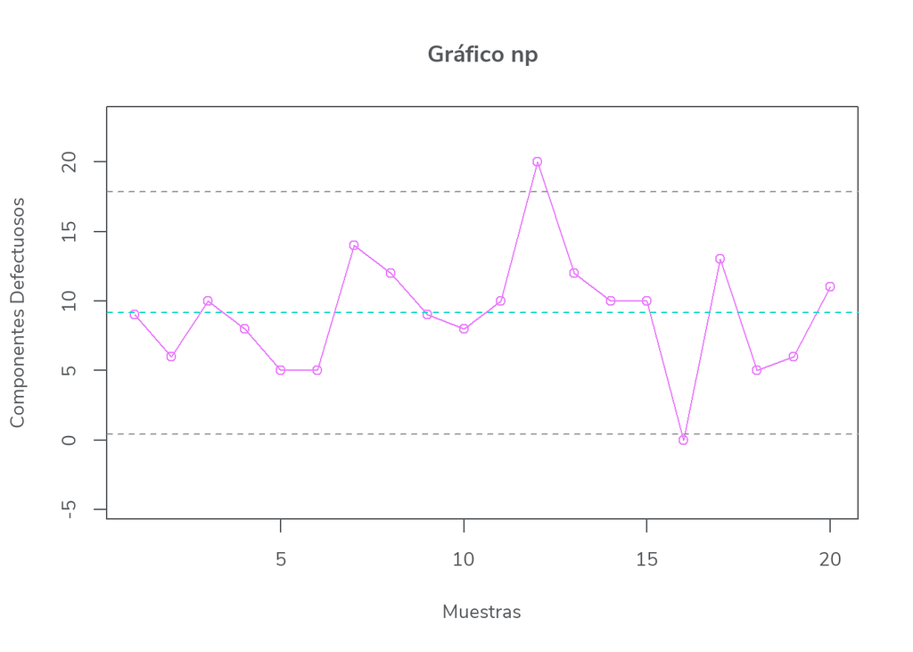

```r
plot(ejemplo2$Componentes.D, type = "o",
     ylim = c(min(ejemplo2$LCI)-5,max(ejemplo2$LCS)+5),
     ylab = "Componentes Defectuosos",
     xlab = "Muestras",
     main = "Gráfico np",
     col = "#EA80FC")
abline(h = ejemplo2$LCS, col = "grey60",lty = 2)
abline(h = ejemplo2$LC, col = "#00DAC6", lty = 2)
abline(h = ejemplo2$LCI, col = "grey60", lty = 2)
```

#### Gráfico $np$ (GGPLOT2)

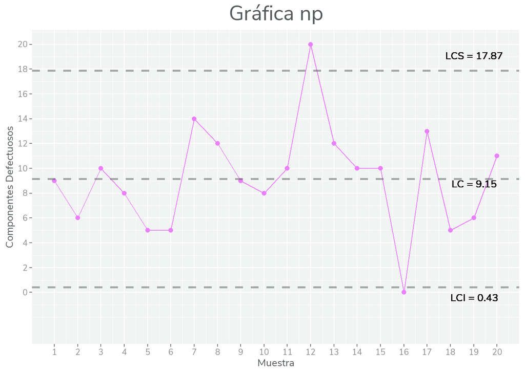

```r
ejemplo2 %>% ggplot(aes(Muestra, Componentes.D))+
  geom_line(size = .5, col = "#EA80FC")+
  geom_point(size = 1.7,col = "#EA80FC")+
  geom_hline(yintercept = c(mean(LCS),
                            mean(LCI),
                            mean(LC)),
             linetype = "dashed",
             size = 1,
             alpha = .5)+
  labs(title = "Gráfica np",
       x = "Muestra",
       y = "Componentes Defectuosos")+
  scale_y_continuous(limits = c(-3,20), breaks = seq(0,20,2))+
  scale_x_continuous(breaks = seq(0,20,1))+
  theme(plot.title = element_text(hjust =.5, size = 20))+
  geom_text(aes(x = 19,
                label = "LCI = 0.43",
                y = 0),
            angle = 0,
            color = "black",
            vjust = 1.2)+
  geom_text(aes(x = 19,
                label = "LCS = 17.87",
                y = 19.5),
            angle = 0,
            color = "black",
            vjust = 1.2)+
  geom_text(aes(x = 19,
                label = "LC = 9.15",
                y = 9.15),
            angle = 0,
            color = "black",
            vjust = 1.2)
```

### Cartas $c$ (número de defectos)

La **Carta c** tiene como objetivo el analizar la variabilidad del número de defectos por subgrupo o unidad con un tamaño de subgrupo constante.

$$\mu_{c_i}= \bar{c} = \frac{Total \space de \space defectos}{Total \space
de \space subgrupos} \space y \space \sigma_{c_i} = \bar{c}\\
LCS = \bar{c}+3\sqrt{\bar{c}}\\
LC = \bar{c}\\
LCI = \bar{c}-3\sqrt{\bar{c}}$$

> Los límites reflejan la variación esperada para el número de defectos por subgrupo.

### Carta $u$ (número de defectos por unidad)

La **Carta $u$** analiza la variación del número promedio de defectos por artículo o unidad de referencia. Se usa cuando el tamaño del subgrupo no es constante.

$$u_i = \frac{c_i}{n_i} u_{\mu_i} = \bar{u}= \frac{Total \space de \space
defectos}{Total \space de \space articulos \space inspeccionados}\\
\sigma_{u_i}=\sqrt{\frac{\bar{u}}{n}}$$

Esta carta sigue una distribución de poisson y sus límites son:

$$LCS = \bar{u} + 3\sqrt{\frac{\bar{u}}{n}}\\
LC = \bar{u} \\
LCI = \bar{u} - 3\sqrt{\frac{\bar{u}}{n}}\\$$

> Nota: Cuando n no es el mismo en todos los subgrupos, entonces se sustituye por el tamaño promedio de los subgrupos n. En la carta u se grafica el número promedio de defectos por unidad.

### Carta $u$ con límites variables

Se aplica cuando el tamaño de subgrupo $n$, es muy variable. Para cada $n_i$ se calcula los límites de control correspondientes.

### Carta $u$ estandarizada

La variable $Z_i$ sigue aproximadamente una distribución normal estándar $(\mu=0,\sigma=1)$. Por lo tanto, la línea central en esta carta es igual a cero, y los límites de control inferior y superior son $-3$ y $3$, respectivamente.

$$z_i=\frac{u_i-\bar{u}}{\sqrt{\frac{\bar{u}}{n_i}}}$$